# Predict_routes

## Answer*

*Summary at the end of the file.

**What variable might be used to distinguish between “Both are the same” and “They differ”?**

I started by thinking about the variable that might be used to differentiate between: “Both are the same” and “They differ”. First, by looking at the pictures, I thought the area between the two routes (estimated and real) might work as a good indicator. If the routes are not parallel (or relatively close to each other) the larger area might indicate the label “They differ”. However, if in two cases, both routes (estimated and real) are relatively parallel but in the first distance is 3 km and in the second 30 km then even though both would be labeled as “Both are the same” the difference in the area would be substantial. On the other hand, what might not differ in both above cases is the difference between route length (estimated and real). Regardless of the distance, the difference between the estimated and real routes should be comparable. It looks like it might work for most of the cases. However, if both paths going from A to B would create more or less a circle, then it is possible that the difference between route lengths would be small and the area between them very big. Even though this scenario looks very unlikely, maybe I should be taken into account. To show that this situation is very unlikely we can consider a similar example in which both routes create somehow a circle where start and end are far from creating a diameter. In this case, even though the area will be big the difference in length between both routes would also be big and an example could be easily assigned to the “They differ” category. Maybe some coefficient between the length difference between routes and the area would be an idea?  
Another variable that might be used to differentiate between “Both are the same” and “They differ” might be the number of turns (or coordination points). However, I do not have a strong conceptual background for this option. It is just an interesting possibility.

**Selected candidate explanatory variables**

- estimated_distance* – Length of the estimated route
- real_distance* - Length of the real route
- start_end_distance – The straight-line distance between the start and the end of the route
- absolute_route_difference – Absolute difference in length between estimated_distance and real_distance. I chose to use absolute instead of relative difference because I assumed that the "annotators", during "annotation" procedure, weren’t interested in which route is which (estimated or real).
- estimated_turns – The number of turns (changes in driving direction) made on the estimated route or, more precisely, the number of coordinate points.
- real_turns – The number of turns (changes in driving direction) made on the real route or, more precisely, the number of coordinate points.
- absolute_turns_difference - Absolute difference in the number of turns between estimated_turns and real_turns.

*I will get a route length in degrees (?). I know that 1-degree longitude has fewer kilometers near Madrid than Quito, however, I don't think converting units is necessary. The "annotators" make their decisions based on images and the distance covered, and even less the unit of measurement does not matter to them (they are not given either).

### Creating the Dataframe

**Loading data and checking the structure**

Provided json file should be a list of dictionaries.

```python
import json

# load json array file as list
with open("challenge_dataset.json", "r") as f:
    data = json.load(f)

f.close()

# check the lint length
len(data)
```

```
3027
```

It looks like instead of 5,000 journeys we have just 3027. Or even less because some should be annotated multiple times.

```python
# check data structure
data[0].keys()
```

```
dict_keys(['journey_id', 'annotator', 'annotation', 'estimated_route', 'real_route'])
```

Data structure according to the description.

Now parse json format data to separated lists (by diccionary keys).

```python
journey_id = []
annotator = []
annotation = []
estimated_route = []
real_route = []

for item in data[:len(data)]:
    journey_id.append(item['journey_id'])
    annotator.append(item['annotator'])
    annotation.append(item['annotation'])
    estimated_route.append(item['estimated_route'])
    real_route.append(item['real_route'])

print(f"""journey_id: {journey_id[:4]} \nannotator: {annotator[:4]} \nannotation: {annotation[:4]}
estimated_route: {estimated_route[0][:4]}... \nreal_route: {real_route[0][:4]}...""")
```

```
journey_id: ['9cd6cd52-54c5-11ec-ae0a-0d030544d074', 'e082d4b5-5932-11ec-8850-c155283d1094', '1c4352c2-5acf-11ec-8cd8-31770dca897a', '1c4352c2-5acf-11ec-8cd8-31770dca897a']
annotator: [3, 3, 2, 7]
annotation: ['Both are the same', 'They differ', 'They differ', 'They differ']
estimated_route: [[-12.11149, -77.04675], [-12.11145, -77.04671], [-12.11139, -77.04664], [-12.11134, -77.04659]]...
real_route: [[-12.111973, -77.047275], [-12.111933, -77.047236], [-12.111811, -77.047122], [-12.111683, -77.046984]]...
```

Looks good. If any of the diccionaries would have different structure (e.g. missing a key) I would get an error message.

**Explanatory variables**

For dataframe (and modeling) we do not need list of coordinates, but something simpler, more easy to handle. So I am making explanatory variables described above. I need to count routes lengths based on lists of coordinates. For that, I used a function that uses Pythagorean equation.

```python
from math import sqrt

def count_distance(coordinates):
    distance = 0
    for i in range(len(coordinates) - 1):
        distance += sqrt((coordinates[i+1][0] - coordinates[i][0])**2 + (coordinates[i+1][1] - coordinates[i][1])**2)
    return distance
```

```python
estimated_distance = []
estimated_turns = []
for coordinate in estimated_route[:len(estimated_route)]:
    turns = len(coordinate)
    path_length = count_distance(coordinate)
    estimated_distance.append(path_length)
    estimated_turns.append(turns)

print(f"estimated_distance: {estimated_distance[:5]}... \nestimated_turns: {estimated_turns[:5]}...")
```

```
estimated_distance: [0.02008193843104172, 0.07584129696170099, 0.060337622682826775, 0.060337622682826775, 0.036991712458151714]...
estimated_turns: [74, 302, 114, 114, 51]...
```

```python
real_distance = []
real_turns = []
for coordinate in real_route[:len(real_route)]:
    turns = len(coordinate)
    path_length = count_distance(coordinate)
    real_distance.append(path_length)
    real_turns.append(turns)

print(f"real_distance: {real_distance[:5]}... \nreal_turns: {real_turns[:5]}...")
```

```
real_distance: [0.021496553622477904, 0.08115514047007112, 0.06308155291164051, 0.06308155291164051, 0.029989313924480718]...
real_turns: [95, 290, 162, 162, 98]...
```

```python
start_end_distance = []
for coordinate in real_route[:len(real_route)]:
    start_end = [coordinate[0], coordinate[-1]]
    path_length = count_distance(start_end)
    start_end_distance.append(path_length)

print(f"start_end_distance: {start_end_distance[:5]}...")
```

```
start_end_distance: [0.016319117776400844, 0.0697467170051755, 0.05527850079370471, 0.05527850079370471, 0.021869378409102025]...
```

```python
absolute_route_difference = [abs(a - b) for a, b in zip(estimated_distance, real_distance)]
absolute_turns_difference = [abs(a - b) for a, b in zip(estimated_turns, real_turns)]

print(f"absolute_route_difference: {absolute_route_difference[:5]}... \nabsolute_turns_difference: {absolute_turns_difference[:5]}...")
```

```
absolute_route_difference: [0.0014146151914361839, 0.005313843508370136, 0.0027439302288137374, 0.0027439302288137374, 0.007002398533670996]...
absolute_turns_difference: [21, 12, 48, 48, 47]...
```

**Create a dataframe**

```python
import pandas as pd

chalenge_dict = {
    "journey_id": journey_id, "annotator": annotator, "annotation": annotation,
    "estimated_distance": estimated_distance, "real_distance": real_distance,
    "start_end_distance": start_end_distance,
    "absolute_route_difference": absolute_route_difference, "estimated_turns": estimated_turns,
    "real_turns": real_turns, "absolute_turns_difference": absolute_turns_difference
}

df = pd.DataFrame(chalenge_dict)
df.head(10)
```

|  | journey_id | annotator | annotation | estimated_distance | real_distance | start_end_distance | absolute_route_difference | estimated_turns | real_turns | absolute_turns_difference |
| --- | --- | --- | --- | --- | --- | --- | --- | --- | --- | --- |
| 0 | 9cd6cd52-54c5-11ec-ae0a-0d030544d074 | 3 | Both are the same | 0.020082 | 0.021497 | 0.016319 | 0.001415 | 74 | 95 | 21 |
| 1 | e082d4b5-5932-11ec-8850-c155283d1094 | 3 | They differ | 0.075841 | 0.081155 | 0.069747 | 0.005314 | 302 | 290 | 12 |
| 2 | 1c4352c2-5acf-11ec-8cd8-31770dca897a | 2 | They differ | 0.060338 | 0.063082 | 0.055279 | 0.002744 | 114 | 162 | 48 |
| 3 | 1c4352c2-5acf-11ec-8cd8-31770dca897a | 7 | They differ | 0.060338 | 0.063082 | 0.055279 | 0.002744 | 114 | 162 | 48 |
| 4 | 57a007c3-5a7d-11ec-82d9-ffcc0820fa8d | 1 | They differ | 0.036992 | 0.029989 | 0.021869 | 0.007002 | 51 | 98 | 47 |
| 5 | 57a007c3-5a7d-11ec-82d9-ffcc0820fa8d | 7 | They differ | 0.036992 | 0.029989 | 0.021869 | 0.007002 | 51 | 98 | 47 |
| 6 | a629ccf4-56fb-11ec-9f3b-97958b4887d3 | 1 | I don't know | 0.161828 | 0.161073 | 0.112721 | 0.000756 | 553 | 248 | 305 |
| 7 | a629ccf4-56fb-11ec-9f3b-97958b4887d3 | 3 | Both are the same | 0.161828 | 0.161073 | 0.112721 | 0.000756 | 553 | 248 | 305 |
| 8 | a629ccf4-56fb-11ec-9f3b-97958b4887d3 | 7 | Both are the same | 0.161828 | 0.161073 | 0.112721 | 0.000756 | 553 | 248 | 305 |
| 9 | d21ec8f8-5b5e-11ec-98f4-cd0eec677407 | 1 | They differ | 0.031303 | 0.033154 | 0.025769 | 0.001851 | 128 | 187 | 59 |

The dataframe looks very nice. Let's check again the number of samples (number of rows) and if some values are missing.

```python
len(df)
```

```
3027
```

```python
df.isnull().values.any()
```

```
False
```

Check if there are some duplicates.

```python
# delete duplicates, leave one copie
df.drop_duplicates(keep='first', inplace=True)
df
```

|  | journey_id | annotator | annotation | estimated_distance | real_distance | start_end_distance | absolute_route_difference | estimated_turns | real_turns | absolute_turns_difference |
| --- | --- | --- | --- | --- | --- | --- | --- | --- | --- | --- |
| 0 | 9cd6cd52-54c5-11ec-ae0a-0d030544d074 | 3 | Both are the same | 0.020082 | 0.021497 | 0.016319 | 0.001415 | 74 | 95 | 21 |
| 1 | e082d4b5-5932-11ec-8850-c155283d1094 | 3 | They differ | 0.075841 | 0.081155 | 0.069747 | 0.005314 | 302 | 290 | 12 |
| 2 | 1c4352c2-5acf-11ec-8cd8-31770dca897a | 2 | They differ | 0.060338 | 0.063082 | 0.055279 | 0.002744 | 114 | 162 | 48 |
| 3 | 1c4352c2-5acf-11ec-8cd8-31770dca897a | 7 | They differ | 0.060338 | 0.063082 | 0.055279 | 0.002744 | 114 | 162 | 48 |
| 4 | 57a007c3-5a7d-11ec-82d9-ffcc0820fa8d | 1 | They differ | 0.036992 | 0.029989 | 0.021869 | 0.007002 | 51 | 98 | 47 |
| ... | ... | ... | ... | ... | ... | ... | ... | ... | ... | ... |
| 3022 | 1ff61866-56e5-11ec-a030-5b2661139648 | 1 | They differ | 0.077301 | 0.077518 | 0.042460 | 0.000217 | 631 | 307 | 324 |
| 3023 | 654af792-5a7d-11ec-8c85-0ff9c4006dcc | 1 | They differ | 0.031511 | 0.033749 | 0.022222 | 0.002238 | 105 | 90 | 15 |
| 3024 | f09bacc5-5b09-11ec-972a-7d407291138a | 7 | They differ | 0.064339 | 0.055279 | 0.030980 | 0.009060 | 288 | 203 | 85 |
| 3025 | 36a4dced-595c-11ec-8996-cd381fc53ce6 | 7 | They differ | 0.123360 | 0.109229 | 0.081459 | 0.014131 | 570 | 387 | 183 |
| 3026 | d8a9a359-57ac-11ec-a9f2-21f25b2beb05 | 2 | They differ | 0.026451 | 0.024201 | 0.013461 | 0.002249 | 153 | 136 | 17 |

2918 rows × 10 columns

### Data exploration

Let's check how look 'the most' row data in our dataframe, so route distances in terms of annotation.

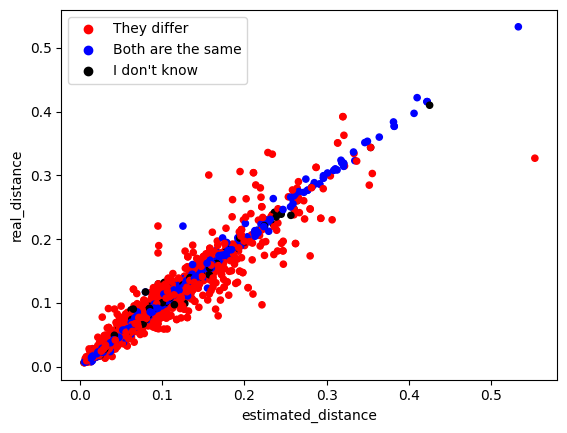

```python
import matplotlib.pyplot as plt
import matplotlib.lines

colors = {'They differ': 'red', 'Both are the same': 'blue','I don\'t know': 'black'}
df["annotation_color"] = [colors[group] for group in df['annotation']]

df.plot(kind = 'scatter', x = 'estimated_distance', y = 'real_distance', c= "annotation_color")
handles = [matplotlib.lines.Line2D([],[], marker="o", color=c, linestyle="none") for c in ["red", "blue", "black"]]
plt.legend(handles=handles, labels=['They differ', 'Both are the same', 'I don\'t know'])
plt.show()
```

It looks like points annotated as 'They differ' are much more scattered around the imaginary regression line than 'Both are the same' dots (blue). This suggests that, as I previously mentioned, the difference between estimated and real routes might be a good variable to distinguish between the two categories. Additionally, it looks like we could have at least one outlier, the red dot most to the right (with the highest estimated_distance value).  
Let's check how absolute_route_difference will explain annotation categories.

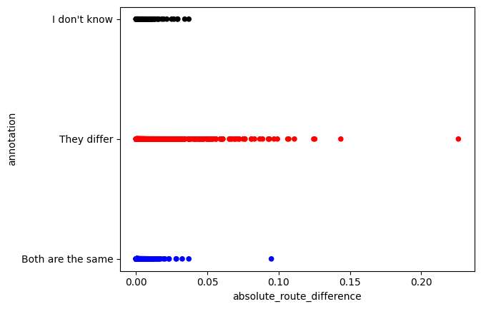

```python
df.plot(kind = 'scatter', x = 'absolute_route_difference', y = 'annotation', c= "annotation_color")
plt.show()
```

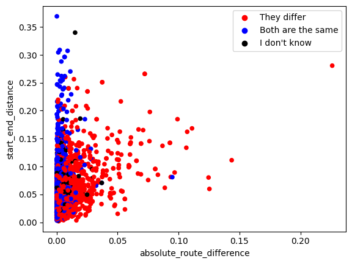

```python
df.plot(kind = 'scatter', x = 'absolute_route_difference', y = 'start_end_distance', c= "annotation_color")
handles = [matplotlib.lines.Line2D([],[], marker="o", color=c, linestyle="none") for c in ["red", "blue", "black"]]
plt.legend(handles=handles, labels=['They differ', 'Both are the same', 'I don\'t know'])
plt.show()
```

'They differ' category has much bigger range than 'Both are the same' and the latter is limited to small values of absolute_route_difference.  
Absolute_route_difference might be a good predictor of annotation.  
Additionally, we can see two potential outliers one red and one blue dots that are the most to the right.  
In second plot I added start_end_distance (shortest distance between start and end of the journey), because I thought that it might help with distinguishing between annotations. It look's like in 'Both are the same' category the absolute_route_difference is totally independent of the journey distance. However, in 'They differ' category absolute_route_difference increase with start_end_distance.

Let's see what is the annotation structure in annotators.

```python
pd.crosstab(df['annotator'], df['annotation'], margins=True)
# df.groupby(['annotator', 'annotation'])['real,_distance'].count()
```

| annotation annotator | Both are the same | I don't know | They differ | All |
| --- | --- | --- | --- | --- |
| 1 | 150 | 22 | 318 | 490 |
| 2 | 309 | 74 | 486 | 869 |
| 3 | 114 | 11 | 155 | 280 |
| 4 | 53 | 12 | 47 | 112 |
| 5 | 5 | 4 | 12 | 21 |
| 6 | 66 | 15 | 155 | 236 |
| 7 | 340 | 39 | 245 | 624 |
| 8 | 113 | 26 | 147 | 286 |
| All | 1150 | 203 | 1565 | 2918 |

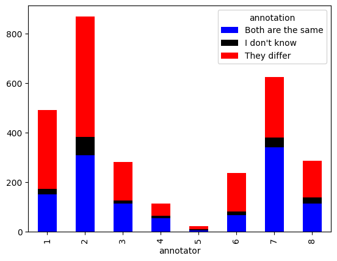

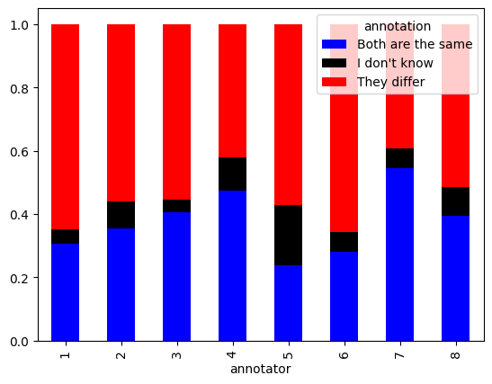

```python
# pd.crosstab(df['annotator'], df['annotation']).plot.bar(alpha=0.5)
pd.crosstab(df['annotator'], df['annotation']).plot(kind="bar", stacked=True, color=[ 'blue', 'black', 'red'])
pd.crosstab(df['annotator'], df['annotation'],normalize='index').plot(kind="bar", stacked=True, color=[ 'blue', 'black', 'red'])
```

Annotators differ in the overall number of given annotations. All except one (nr 5) annotated more than 100 journeys. Additionally, annotations given by annotator nr 5 had a higher proportion of 'I don't know' label. Proportions of different annotations made by other annotators look roughly similar. Taking all this into account I would exclude annotations made by annotator nr 5. The small number of annotations made by this annotator and its pattern might bias the model.  
I will also remove two outliers identified before.

Additionally, I decided to remove all 'I don't know' annotations from the dataset, because this category won't be useful for the training model, since we want to teach it to distinguish 'the same' from 'differ'.

```python
# drop outliers, one red and blue with the highest value of absolute_route_difference
max_red = df["absolute_route_difference"].max()
df.drop(df[df.absolute_route_difference == max_red].index, inplace= True)
max_blue = df[df.annotation == "Both are the same"]["absolute_route_difference"].max()
df.drop(df[df.absolute_route_difference == max_blue].index, inplace= True)
```

```python
df.drop(df[df.annotation == "I don't know"].index, inplace= True)
df.drop(df[df.annotator == 5].index, inplace= True)
len(df)
```

```
2696
```

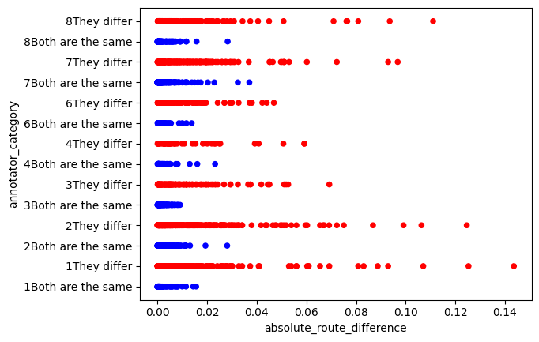

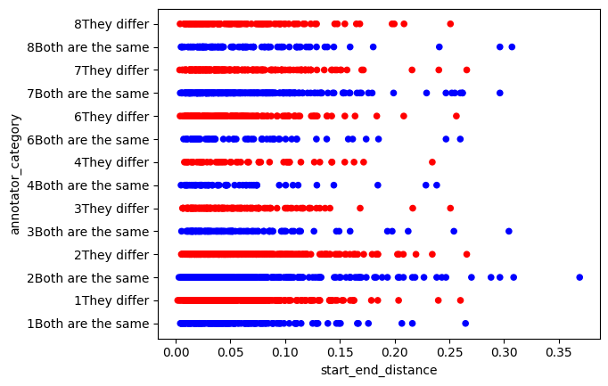

```python
df['annotator_category'] = df['annotator'].astype(str) + df['annotation']
df = df.sort_values(by=['annotator_category'])
df.plot(kind = 'scatter', x = 'absolute_route_difference', y = 'annotator_category', c= "annotation_color")
plt.show()

df.plot(kind = 'scatter', x = 'start_end_distance', y = 'annotator_category', c= "annotation_color")
plt.show()
```

Annotations have similar patterns in terms of absolute_route_difference values across all annotators.  
Also it looks like journeys were randomly distributed between annotators, at least in terms of start_end_distance.  
The one thing that I do not like is the difference in the range of the absolute_route_difference between the groups. Most of the blue data points are clustered near 0. To fix these log transformation might be used.

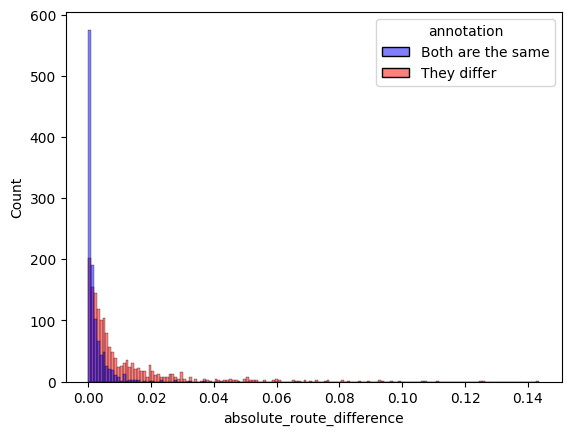

```python
import numpy as np
import seaborn as sns

df['log_absolute_route_difference'] = np.log(df['absolute_route_difference'])
sns.histplot(x = "absolute_route_difference", hue = "annotation", palette = ['blue', 'red'], data = df)
```

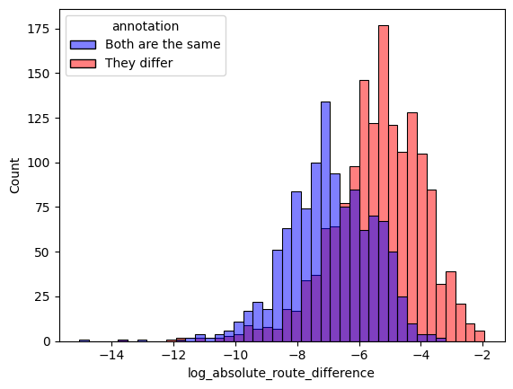

```python
sns.histplot(x = "log_absolute_route_difference", hue = "annotation", palette = ['blue', 'red'], data = df)
```

Now the distribution looks much better.

So far I didn't check the other potencial indicator of annotation: 'the same' or 'differ', that is number of turns. Let's have a look now.

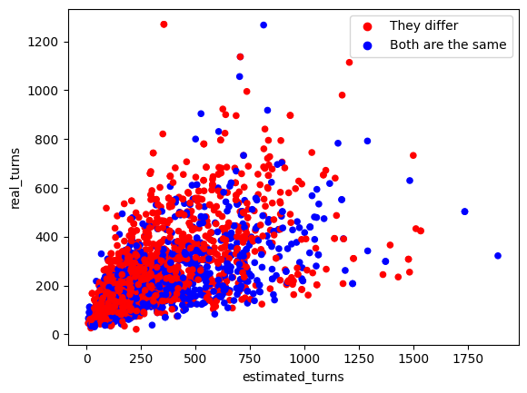

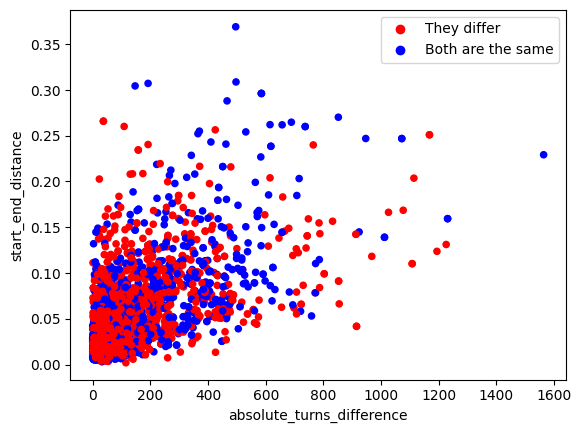

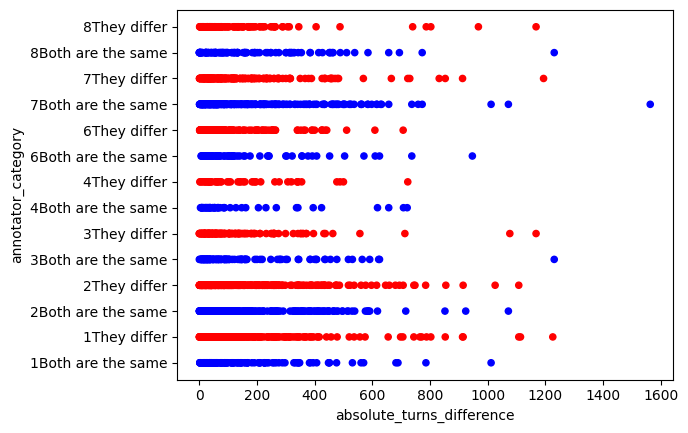

```python
df.plot(kind = 'scatter', x = 'estimated_turns', y = 'real_turns', c= "annotation_color")
handles = [matplotlib.lines.Line2D([],[], marker="o", color=c, linestyle="none") for c in ["red", "blue"]]
plt.legend(handles=handles, labels=['They differ', 'Both are the same'])
plt.show()

df.plot(kind = 'scatter', x = 'absolute_turns_difference', y = 'start_end_distance', c= "annotation_color")
plt.legend(handles=handles, labels=['They differ', 'Both are the same'])
plt.show()

df.plot(kind = 'scatter', x = 'absolute_turns_difference', y = 'annotator_category', c= "annotation_color")
plt.show()
```

Doesn't look like the number of turns might help us to distinguish between 'Both are the same' and 'They differ' categories.

Finally let's have a look on 'journey_id' variable, as like we know from challenge description "Note that each journey may have more than one annotation".

```python
# group data by journey_id
journey_df = df.groupby(["journey_id"]).size().reset_index(name='Number of annotators per journey')
journey_df.groupby("Number of annotators per journey").size().reset_index(name='Number of journeys')
```

|  | Number of annotators per journey | Number of journeys |
| --- | --- | --- |
| 0 | 1 | 1810 |
| 1 | 2 | 412 |
| 2 | 3 | 18 |
| 3 | 4 | 2 |

```python
# show the journeys that were annotated by 4 annotetors
journey_4_scores_list = list(journey_df[journey_df['Number of annotators per journey'] == 4]['journey_id'])
df[df["journey_id"].isin(journey_4_scores_list)][['journey_id','annotation','annotator']].sort_values(by=['journey_id'])
```

|  | journey_id | annotation | annotator |
| --- | --- | --- | --- |
| 63 | 8888e1c8-571e-11ec-b5bd-875b7e183cb7 | Both are the same | 1 |
| 61 | 8888e1c8-571e-11ec-b5bd-875b7e183cb7 | Both are the same | 2 |
| 62 | 8888e1c8-571e-11ec-b5bd-875b7e183cb7 | Both are the same | 3 |
| 60 | 8888e1c8-571e-11ec-b5bd-875b7e183cb7 | Both are the same | 7 |
| 1195 | b3df0630-54a3-11ec-b344-ab8c7bd1aa5c | Both are the same | 2 |
| 1194 | b3df0630-54a3-11ec-b344-ab8c7bd1aa5c | Both are the same | 4 |
| 1193 | b3df0630-54a3-11ec-b344-ab8c7bd1aa5c | They differ | 6 |
| 1192 | b3df0630-54a3-11ec-b344-ab8c7bd1aa5c | Both are the same | 7 |

As you can see 432 journeys were annotated by more than 1 person, maximum by 4. We are dealing here with repeated measures.

The way to deal with this issue is to leave up to one annotation per journey. The conditions will be as follows:

1. The most abundant annotation per journey will be kept (e.g. If 4 people annotate a journey annotation that appeared 3 or 4 times will be kept).
2. From rows kept in the previous point only one will be kept at random.
3. In case when the number of annotations in both groups are equal (the same amount of 'Both are the same' and 'They differ') then such a journey will be reomved from the dataframe.

```python
journey_1_list = list(journey_df[journey_df['Number of annotators per journey'] == 1]['journey_id'])
journey_234_list = list(journey_df[journey_df['Number of annotators per journey'] != 1]['journey_id'])
df[df["journey_id"].isin(journey_234_list)]
df_journey_234 = df[df["journey_id"].isin(journey_234_list)].copy()

# reduce dataframe to those journeys that have only one annotation
df = df[df["journey_id"].isin(journey_1_list)]

# add, up to one row, to df for each journey that was annotated more than once
for journey_id in journey_234_list:
    journey_temp = df_journey_234[df_journey_234["journey_id"] == journey_id]
    df_the_same = journey_temp[journey_temp["annotation"] == "Both are the same"]
    the_same = df_the_same["annotation"].count()
    df_they_differ = journey_temp[journey_temp["annotation"] == "They differ"]
    they_differ = df_they_differ["annotation"].count()
    if the_same >= 2:
        df = df._append(df_the_same.sample())
    elif they_differ >= 2:
        df = df._append(df_they_differ.sample())


len(df)
```

```
2204
```

Creat dummy variable.

```python
df["annotation_dummy"] = df["annotation"].copy()
df.loc[df["annotation_dummy"] == "Both are the same","annotation_dummy"] = 0
df.loc[df["annotation_dummy"] == "They differ", "annotation_dummy"] = 1
df["annotation_dummy"] = pd.to_numeric(df["annotation_dummy"])
df[["annotation", "annotation_dummy"]]
```

|  | annotation | annotation_dummy |
| --- | --- | --- |
| 2102 | Both are the same | 0 |
| 878 | Both are the same | 0 |
| 751 | Both are the same | 0 |
| 2738 | Both are the same | 0 |
| 2411 | Both are the same | 0 |
| ... | ... | ... |
| 126 | They differ | 1 |
| 1664 | They differ | 1 |
| 744 | They differ | 1 |
| 2080 | They differ | 1 |
| 146 | They differ | 1 |

2204 rows × 2 columns

### Final dataset - summary

```python
df.info()
df.describe()
```

```
<class 'pandas.core.frame.DataFrame'>
Index: 2204 entries, 2102 to 146
Data columns (total 14 columns):
 #   Column                         Non-Null Count  Dtype
---  ------                         --------------  -----
 0   journey_id                     2204 non-null   object
 1   annotator                      2204 non-null   int64
 2   annotation                     2204 non-null   object
 3   estimated_distance             2204 non-null   float64
 4   real_distance                  2204 non-null   float64
 5   start_end_distance             2204 non-null   float64
 6   absolute_route_difference      2204 non-null   float64
 7   estimated_turns                2204 non-null   int64
 8   real_turns                     2204 non-null   int64
 9   absolute_turns_difference      2204 non-null   int64
 10  annotation_color               2204 non-null   object
 11  annotator_category             2204 non-null   object
 12  log_absolute_route_difference  2204 non-null   float64
 13  annotation_dummy               2204 non-null   int64
dtypes: float64(5), int64(5), object(4)
memory usage: 258.3+ KB
```

|  | annotator | estimated_distance | real_distance | start_end_distance | absolute_route_difference | estimated_turns | real_turns | absolute_turns_difference | log_absolute_route_difference | annotation_dummy |
| --- | --- | --- | --- | --- | --- | --- | --- | --- | --- | --- |
| count | 2204.000000 | 2204.000000 | 2204.000000 | 2204.000000 | 2.204000e+03 | 2204.000000 | 2204.000000 | 2204.000000 | 2204.000000 | 2204.000000 |
| mean | 3.994102 | 0.081737 | 0.081427 | 0.057104 | 7.056476e-03 | 326.563067 | 238.823503 | 144.067151 | -6.064351 | 0.573503 |
| std | 2.574088 | 0.065747 | 0.065729 | 0.047094 | 1.284750e-02 | 262.119707 | 156.678828 | 174.071255 | 1.660705 | 0.494680 |
| min | 1.000000 | 0.005732 | 0.005990 | 0.001888 | 2.902446e-07 | 8.000000 | 21.000000 | 0.000000 | -15.052542 | 0.000000 |
| 25% | 2.000000 | 0.035394 | 0.035066 | 0.023622 | 8.116078e-04 | 132.000000 | 129.000000 | 34.000000 | -7.116496 | 0.000000 |
| 50% | 3.000000 | 0.061647 | 0.062045 | 0.043267 | 2.690674e-03 | 246.000000 | 198.000000 | 78.000000 | -5.917965 | 1.000000 |
| 75% | 7.000000 | 0.106758 | 0.107066 | 0.075826 | 7.244629e-03 | 452.500000 | 305.000000 | 186.500000 | -4.927496 | 1.000000 |
| max | 8.000000 | 0.532920 | 0.533093 | 0.369077 | 1.435960e-01 | 1886.000000 | 1270.000000 | 1564.000000 | -1.940752 | 1.000000 |

```
Total number of observations: 2204

Ptoportion of journeys annotated as 'The same' and 'Different'
```

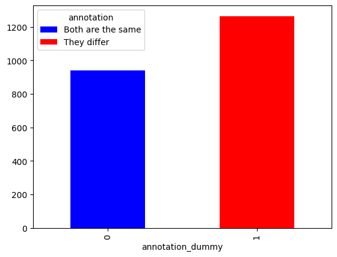

```python
print(f"Total number of observations: {len(df)} \n \nPtoportion of journeys annotated as 'The same' and 'Different'")
pd.crosstab(df['annotation_dummy'], df['annotation']).plot(kind="bar", stacked=True, color=['blue', 'red'])
```

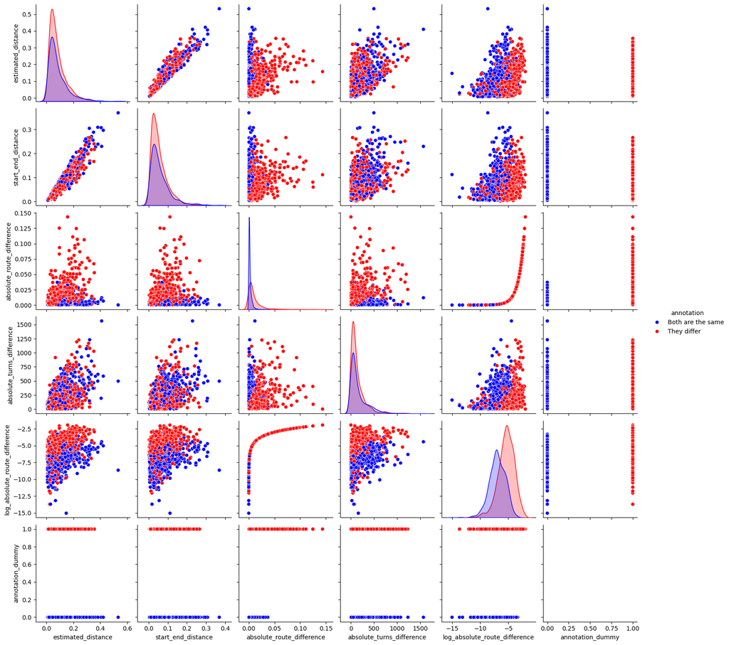

```python
df_for_plot = df[['estimated_distance', 'start_end_distance', 'absolute_route_difference','absolute_turns_difference', 'log_absolute_route_difference', 'annotation_dummy', 'annotation']].copy()
sns.pairplot(df_for_plot, hue='annotation', palette = ['blue', 'red'])
```

It looks like annotation, a binary variable, ('Both the same' - 0, and 'They differ' - 1) might be nicely predicted by absolute_route_difference or log_absolute_route_difference using Logistic Regression model (check the lowest series of plots). From those two variables better would be log-transformed one, because data ranges per annotation and distributions look better.  
As for other variables that might help to predict annotation any variable that is an estimate of the journey length, check the series of plots for log_absolute_route_difference to see that points segregate into two groups. I can choose only one of those variables to add to the model because all of them are more or less correlated (see plot below). I decided to go on with start_end_distance, however, an equally good choice would be an average between estimated_distance and real_distance.

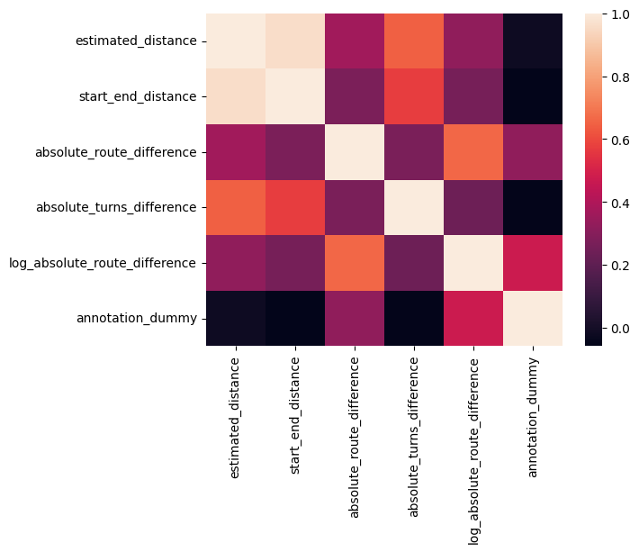

```python
sns.heatmap(df_for_plot.iloc[:, :6].corr())
```

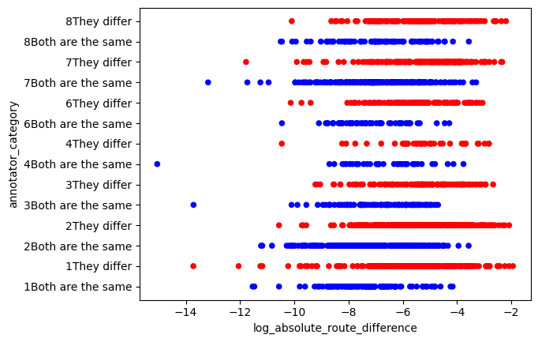

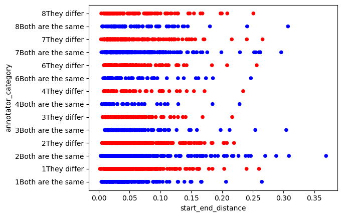

```python
df.plot(kind = 'scatter', x = 'log_absolute_route_difference', y = 'annotator_category', c= "annotation_color")
plt.show()
df.plot(kind = 'scatter', x = 'start_end_distance', y = 'annotator_category', c= "annotation_color")
plt.show()
```

As for the annotators, normally I would add this variable as a random effect to the model. However, even adding it to the model as a fixed factor should not affect the dependent variable (annotation), judging from the above plots (similar points distribution pattern between annotators).  
What's more, if I train and test a model for future use I should use variables that will always be available. If I use an annotator as an explanatory variable to train a model I should supply this info to predict annotation, but what I understand the idea is that in the future there won't be any annotator.  
Variable 'annotator' will not be included in the model.

Finally, I would like to add that the area size between the estimated and real route might be a good annotation estimator, however, I couldn't find a quick way to produce such data.

### Model

**Logistic Regression model: annotation_dummy ~ log_absolute_route_difference + start_end_distance**

```python
from sklearn.model_selection import train_test_split
X = df[['start_end_distance','log_absolute_route_difference']]
y = df['annotation_dummy']
X_train, X_test,y_train, y_test = train_test_split(X,y,test_size=0.25, random_state=0)

from sklearn.linear_model import LogisticRegression
logreg = LogisticRegression()
logreg.fit(X_train,y_train)

from sklearn.metrics import confusion_matrix, classification_report
y_pred = logreg.predict(X_test)
print(confusion_matrix(y_test, y_pred))

print(classification_report(y_test,y_pred))
```

```
[[147  91]
 [ 58 255]]
              precision    recall  f1-score   support

           0       0.72      0.62      0.66       238
           1       0.74      0.81      0.77       313

    accuracy                           0.73       551
   macro avg       0.73      0.72      0.72       551
weighted avg       0.73      0.73      0.73       551
```

Results:

- True negatives(TN): 147
- False negatives(FN): 58
- False positives(FP): 91
- True positives(TP): 255

**Model accuracy: 73%**

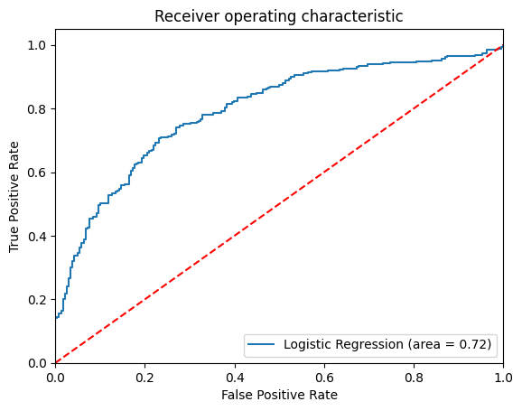

```python
from sklearn.metrics import roc_auc_score
from sklearn.metrics import roc_curve
logit_roc_auc = roc_auc_score(y_test, logreg.predict(X_test))
fpr, tpr, thresholds = roc_curve(y_test, logreg.predict_proba(X_test)[:,1])
plt.figure()
plt.plot(fpr, tpr, label='Logistic Regression (area = %0.2f)' % logit_roc_auc)
plt.plot([0, 1], [0, 1],'r--')
plt.xlim([0.0, 1.0])
plt.ylim([0.0, 1.05])
plt.xlabel('False Positive Rate')
plt.ylabel('True Positive Rate')
plt.title('Receiver operating characteristic')
plt.legend(loc="lower right")
plt.savefig('Log_ROC')
plt.show()
```

### Summary

1. Loading data - list of diccionarys.
2. 3027 journeys (samples) instead of 5000.
3. Transform routes coordinates to more useful explanatory variables like: absolute_route_difference (absolute difference in length between estimated_distance and real_distance) and start_end_distance (the straight-line distance between the start and the end of the route).
4. Creating dataframe.
5. Check for missing values.
6. Delete duplicated rows - 2918 samples left.
7. Data exploration:
   - creating plots to check distributions and look for patterns in the data
   - deleting annotator nr 5, because of a small number of annotations made (21) and difference in annotation pattern compared to other annotators, which could bias the model.
   - drop all "I don't know" annotations from the dataset - 2696 samples left.
   - log transforming absolute_route_difference variable - log_absolute_route_difference
   - dealing with repeated measures - 2204 samples left
   - final dataset exploration - e.g. checking variables correlation
8. Choosing model - logistic regression.
9. Building a model: annotation_dummy ~ log_absolute_route_difference + start_end_distance
10. Training and testing the model.
11. Result - model accuracy: 73%.